# Parte 4

Diego Ernesto

Wednesday, November 05, 2014

***PS: não fiz uppload do banco de dados devido ao seu grande tamanho. Nesses scripts uso o track_metadata.db e o subset_artist_term.db**

*Qual o ano de lançamento tem o maior sucesso atual nas radios?*

Sabendo que o banco de dados mostra apenas o sucesso atual da faixa nas radios e o ano de lancamento da faixa, podemos fazer uma comparacao desses atributos no grafico abaixo:

Podemos ver que o ano com o maior sucesso nas radios atuais (mediana) é o ano de 1965, embora (devido ao tamnho do ponto) possamos notar que poucas faixas lancadas nesse ano estão contidas na lista. O que pode indicar um grande sucesso especifico. Podemos tambem observar que a quantidade de faixas e também de sucesso dos primeiros anos é bem inferior aos demais. O numero de faixas lancaças e o crescimento do sucesso-influencia nas radios atuais tem um crescimento linear ate meados dos anos 1970. A partir dos anos 80 temos um crescimento mais estavel do sucesso medio de cada um dos ano, mas continua o crescimento do numero de faixas lançadas (o que era de se esperar).

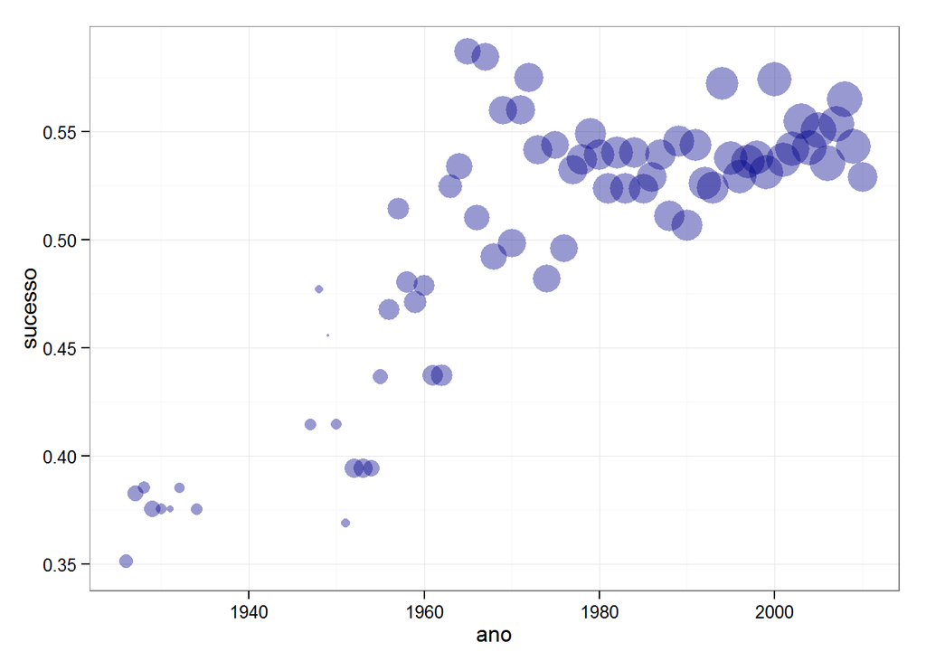

*Qual o crescimento da duração das faixas ao longo dos anos? consegue existir alguma relação com o sucesso?*

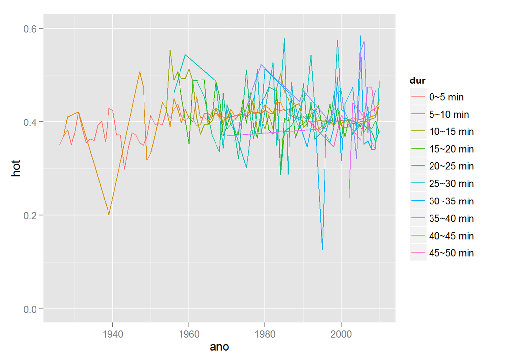

[figure not shown]